# IODS course project

## Numerical and Graphical results

```
## # A tibble: 4 x 7
## # Groups:   sex [2]
##   sex   high_use count mean_health mean_grade mean_family_relati~ mean_going_out
##   <chr> <lgl>    <int>       <dbl>      <dbl>               <dbl>          <dbl>
## 1 F     FALSE      156        3.38       11.4                3.91           2.96
## 2 F     TRUE        42        3.40       11.7                3.76           3.36
## 3 M     FALSE      112        3.71       12.2                4.13           2.71
## 4 M     TRUE        72        3.88       10.3                3.79           3.93
```

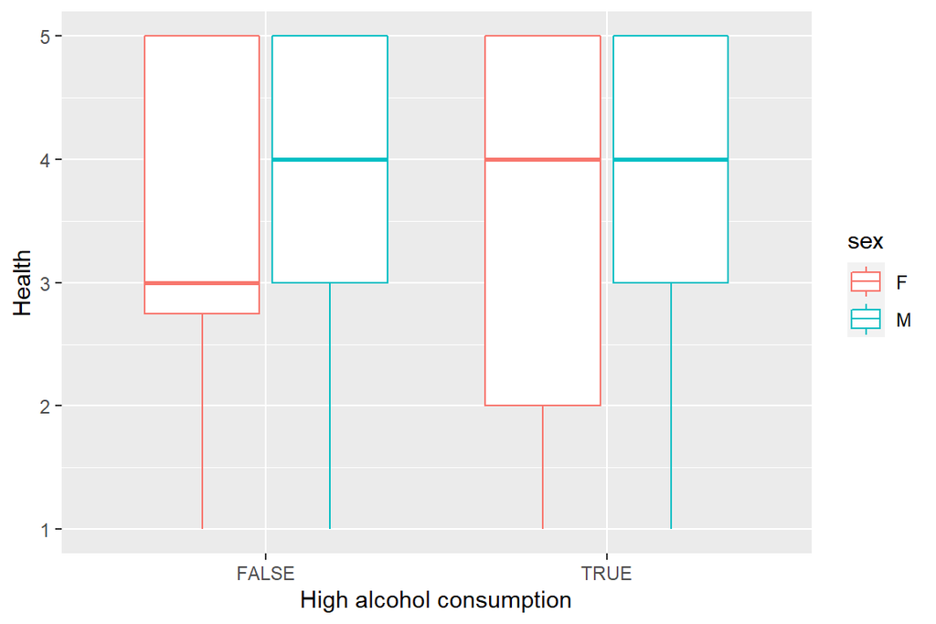

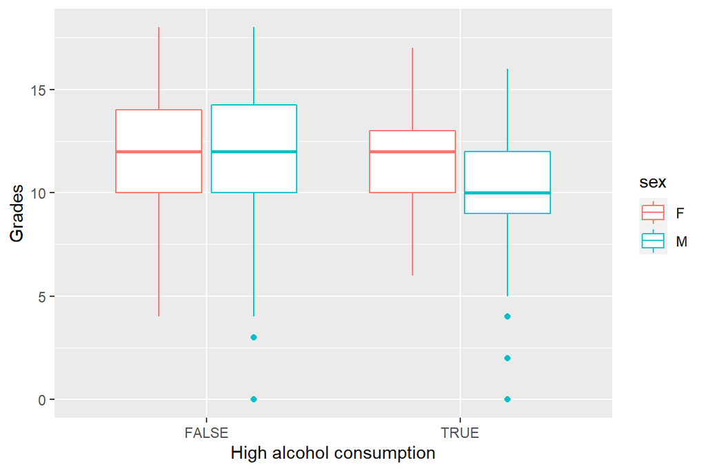

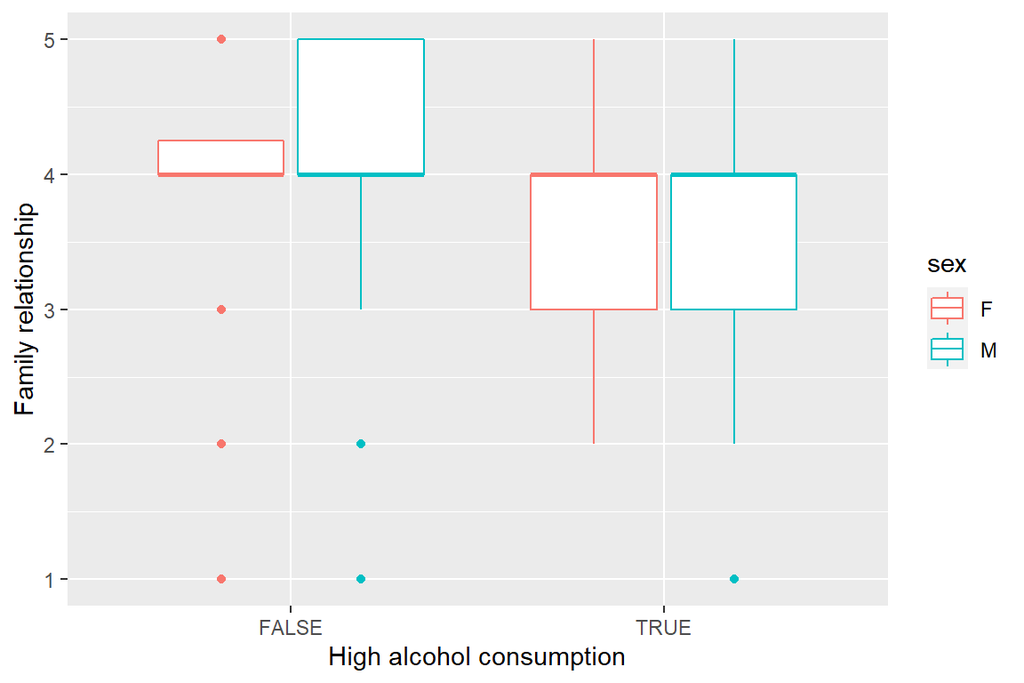

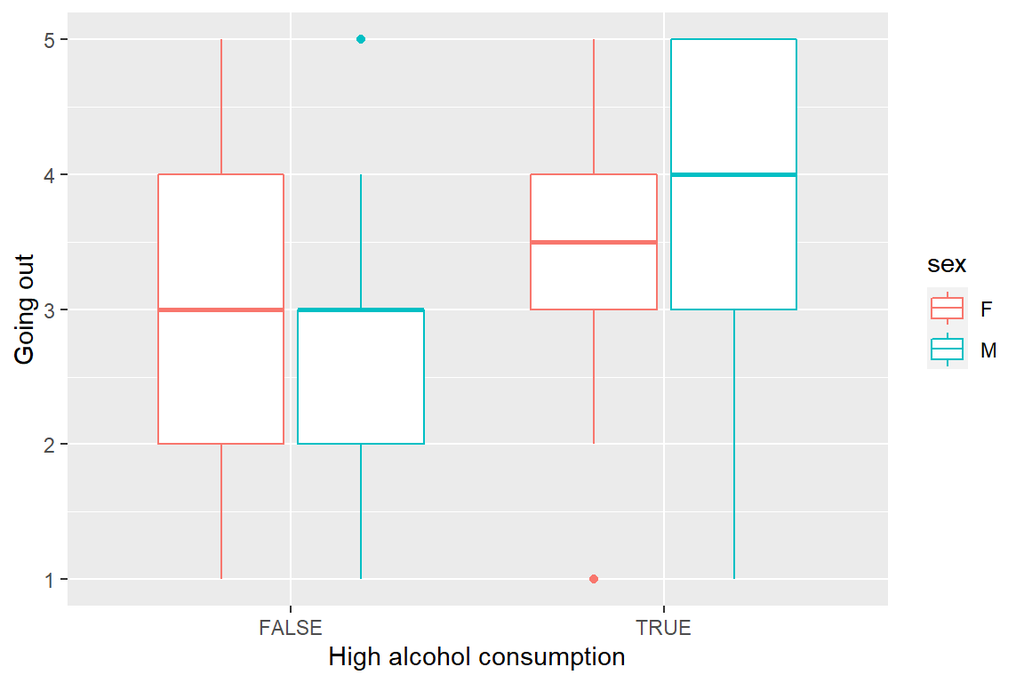

The table shows the average grades and scores for health, grade and family relationship. They are splited into four categories depending on geneder and whether there is high usage of alcohol. The box plot shows the spread of the 4 variables compared to alcohol consumption.

It seems that for H1, the usage of alcohol does not really affect the quality of life. They share similar mean score and most of them have median at 4. It seems that females not having high usage of alcohol may have poorer health due to lower median, but a majority of them stays in the higher score region. Therefore, H1 is unlikely to happen.

For H2, both females have very similar mean grades, while males who do not drink as much have higher mean grades than their counterpart. This observation is also evident from the box plot, but requires more in-depth analysis to prove this hypothesi since the females are not affected.

Regardless of gender, H3 may be likely as the mean scores of family relationship for high consumption of alcohol are lower. While they all share very similar median, The box plot also shows that a majority of high usage drinkers are below the median, while for low usage drinkers the scores are above the median.

Lastly, high usage drinkers are more likely to go out than low usage for both genders. THis observation is more prominent for males.

```
##
## Call:
## glm(formula = high_use ~ health + G3 + famrel + goout, family = "binomial",
##     data = alc)
##
## Deviance Residuals:
##     Min       1Q   Median       3Q      Max
## -1.5311  -0.7918  -0.5631   0.9483   2.3954
##
## Coefficients:
##             Estimate Std. Error z value Pr(>|z|)
## (Intercept) -1.96248    0.83894  -2.339  0.01932 *
## health       0.14820    0.09088   1.631  0.10292
## G3          -0.04359    0.03801  -1.147  0.25141
## famrel      -0.38870    0.13654  -2.847  0.00442 **
## goout        0.78532    0.11974   6.558 5.44e-11 ***
## ---
## Signif. codes:  0 '***' 0.001 '**' 0.01 '*' 0.05 '.' 0.1 ' ' 1
##
## (Dispersion parameter for binomial family taken to be 1)
##
##     Null deviance: 465.68  on 381  degrees of freedom
## Residual deviance: 403.43  on 377  degrees of freedom
## AIC: 413.43
##
## Number of Fisher Scoring iterations: 4
```

From the P value, going out has the lowest P value, followed by family relationship. This means that they are be significant enough to be correlated to alcohol consumption.

```
##                    OR      2.5 %    97.5 %
## (Intercept) 0.1405097 0.02622717 0.7098938
## health      1.1597481 0.97258747 1.3899979
## G3          0.9573426 0.88846075 1.0316143
## famrel      0.6779358 0.51695340 0.8846371
## goout       2.1931134 1.74534860 2.7937223
```

```
##     famrel goout high_use probability prediction
## 373      4     2    FALSE  0.23047493      FALSE
## 374      5     3     TRUE  0.23279324      FALSE
## 375      5     3    FALSE  0.18537567      FALSE
## 376      4     3    FALSE  0.31668224      FALSE
## 377      5     2    FALSE  0.14035989      FALSE
## 378      4     4    FALSE  0.32061951      FALSE
## 379      2     2    FALSE  0.35374866      FALSE
## 380      1     1    FALSE  0.26909455      FALSE
## 381      2     5     TRUE  0.71431011       TRUE
## 382      4     1     TRUE  0.08114479      FALSE
```

```
##         prediction
## high_use FALSE TRUE
##    FALSE   244   24
##    TRUE     75   39
```

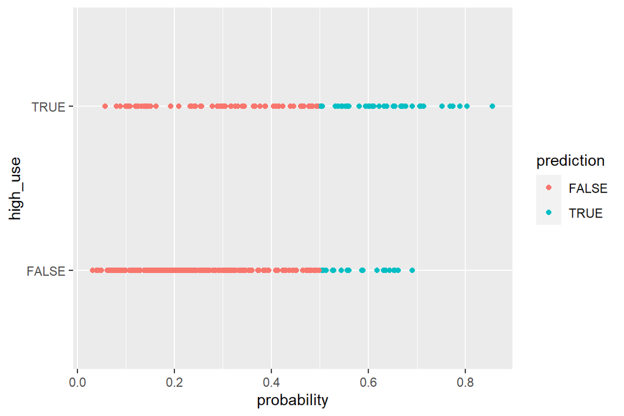

```
##         prediction
## high_use      FALSE       TRUE        Sum
##    FALSE 0.63874346 0.06282723 0.70157068
##    TRUE  0.19633508 0.10209424 0.29842932
##    Sum   0.83507853 0.16492147 1.00000000
```

```
## [1] 0.2591623
```

```
## [1] 0.2696335
```